# S, R, and Data Science

##### Muizz Aman Khan<sup>1</sup> Martin Tran<sup>1</sup>

<sup>1</sup> STAT 405 · Advanced Data Computing · iheiddown

# Background

Data science consists of techniques and their application to derive and communicate scientifically valid inferences and predictions based on relevant data. Stemming its roots to **data-analysis research at Bell Labs** (1960s–70s), inspired by John Tukey who pioneered data analysis. R is the open-source programming language heir to their goals of creating an collaborative and interactive environment (Chambers 2020).

# Three Design Principles

R’s design in follows three ideas, all present since the first S:

- **Objects** — everything that exists is an object
- **Functions** — everything that happens is a function call
- **Interfaces** — Compatibility to other languages (Fortran, C, C++) are built in

# Why It Matters for Data Science

- The **data frame** — a table of observations × variables. It became the central structure for scientific data.
- **Models as objects** encouraged interactive exploration and visualization.
- The **package repositories + CRAN** turned R into a vast, easy-to-use system.

# Major Changes: S → R

R is based off S’s design but added key innovations of its own:

- **Open-source & free** — R is a free “GNU S”; S is licensed (changed ownership with S-Plus).
- **Packages + CRAN** — a standardized structure and central repository; Chambers claimed packages as R’s most important feature.
- **Lexical scoping** — From Scheme/Lisp; object references changes environment.
- **Lazy evaluation** — arguments are evaluated only when needed, via “promise” objects.

# From S to Today

The core ideas from S still anchor modern data science:

| S | Lives on today as |
| --- | --- |
| Data frame | retained `data.frame` object type |
| Vectorization | Default for math & logic |
| `NA` concept | `NA` used across char, numeric types |
| Language Interfaces | Rcpp, Fortran, C++ |
| Package sharing | CRAN (20,000+ packages) |
| First-class Visualizations | ggplot2, base model graphics |

# Conclusion

R wasn’t designed to do specific tasks and jobs that happened to suit data science, it was shaped *by* passionate data analysis researchers since the beginning to create a language that allows many to have an interactive environment to work with data.

# References

Chambers, John M. 2020. “S, r, and Data Science.” *The R Journal* 11 (1): 462–76.

**The evolution of S into R**

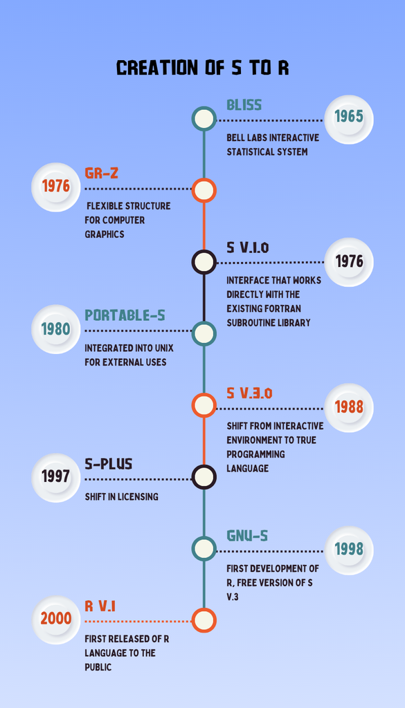

[figure not shown]